# 04_D_Classical_Decomposition_fromScratch

Author

Juan Garbayo - TS Analysis

# References

NOTE: this material is not original, but rather an extension of the following reference, which is publicly available.

1. Hyndman, R.J., & Athanasopoulos, G., 2021. *Forecasting: principles and practice*. 3rd edition. [Link](https://otexts.com/fpp3/)

# Packages

```r
library(fpp3)
```

# Classical decomposition

It is the starting point for most other methods of time series decomposition. In addition, it is simple enough that it can be easily implemented from scratch, which is something we are going to do in class.

Essentially are 2 variants of classical decomposition:

- Classical decomposition of **aditive schemes**
- Classical decomposition of **multiplicative schemes**

The algorithm depends on **whether the length seasonal period is even or uneven.** Examples:

- If we have daily data we may consider, for example, a period of one week. That seasonal period would be of length 7 (7 days).
  - NOTE: For daily data we could also consider other seasonal periods: one month, one quarter… even one year.
- If we have monthly data, we could consider a yearly seasonal period. That seasonal period would be of length 12 (12 months).
- If we have quarterly data, we could consider a yearly seasonal period. That seasonal period would be of length 4 (4 quarters).
- …

Because the algorithm **approximates the trend with a centered moving average**, the even or uneven nature of the seasonal period is important. See the separate notebook on moving averages, which has an associated video to understand this:

- **Even seasonal period ($m$ even):** trend approximated by a 2 x $m$ moving average.
- **Uneven seasonal period $m$:** trend approximated by an $m$ moving average.

# Additive schemes - classical decomposition

## Step 1 - Estimate trend

$m$: length of the seasonal period.

- If $m$ is an even number, compute the trend-cycle component $T_t$ using 2 x $m$-MA.
- If $m$ is an odd number compute the trend-cycle component $T_t$ using an $m$-MA.

**Output**: the **trend component $T_t$**

## Step 2 - Detrended series

Calculate the de-trended series: $D_t = y_t - T_t$

**Output**: the **detrended series $D_t$**

## Step 3 - Compute seasonal component

In classical decomposition, there is a **main assumption to compute the seasonal component**, namely, that it **remains constant over time**. The process will therefore consist in:

1. Compute the shape of the seasonal component over a single season (steps 3.1 and 3.2 below).
2. Chain the previous output to cover the entire timespan of the time series.

Remember that, in out notation, **the length of a season (number of timesteps in a season) is denoted with the leter $m$**

#### Step 3.1. Obtain the unadjusted seasonal component $S_{unadj}$ by averaging the values of the detrended series over the season.

This is **best explained with an example**. Imagine we have monthly data and we have already computed the detrended series. We may add an additional column signaling the month of the year of each datapoint. If we assume that we have $T$ datapoints, our data thus far would have the following structure:

| $t$ | ym | $y_t$ | $T_t$ | $D_t$ (detrended) | month |
| --- | --- | --- | --- | --- | --- |
| $1$ | mar-13 | $y_{1}$ | $\text{T}_{1}$ | $\text{D}_{1}$ | 3 |
| $2$ | abr-13 | $y_{2}$ | $\text{T}_{2}$ | $\text{D}_{2}$ | 4 |
| $3$ | may-13 | $y_{3}$ | $\text{T}_{3}$ | $\text{D}_{3}$ | 5 |
| $4$ | jun-13 | $y_{4}$ | $\text{T}_{4}$ | $\text{D}_{4}$ | 6 |
| $5$ | jul-13 | $y_{5}$ | $\text{T}_{5}$ | $\text{D}_{5}$ | 7 |
| $6$ | ago-13 | $y_{6}$ | $\text{T}_{6}$ | $\text{D}_{6}$ | 8 |
| $7$ | sep-13 | $y_{7}$ | $\text{T}_{7}$ | $\text{D}_{7}$ | 9 |
| $8$ | oct-13 | $y_{8}$ | $\text{T}_{8}$ | $\text{D}_{8}$ | 10 |
| $9$ | nov-13 | $y_{9}$ | $\text{T}_{9}$ | $\text{D}_{9}$ | 11 |
| $10$ | dic-13 | $y_{10}$ | $\text{T}_{10}$ | $\text{D}_{10}$ | 12 |
| $11$ | ene-14 | $y_{11}$ | $\text{T}_{11}$ | $\text{D}_{11}$ | 1 |
| $12$ | feb-14 | $y_{12}$ | $\text{T}_{12}$ | $\text{D}_{12}$ | 2 |
| $13$ | mar-14 | $y_{13}$ | $\text{T}_{13}$ | $\text{D}_{13}$ | 3 |
| $14$ | abr-14 | $y_{14}$ | $\text{T}_{14}$ | $\text{D}_{14}$ | 4 |
| … | … | … | … | … | … |
| $T\!-\!4$ | ago-20 | $y_{T-4}$ | $\text{T}_{T-4}$ | $\text{D}_{T-4}$ | 8 |
| $T\!-\!3$ | sep-20 | $y_{T-3}$ | $\text{T}_{T-3}$ | $\text{D}_{T-3}$ | 9 |
| $T\!-\!2$ | oct-20 | $y_{T-2}$ | $\text{T}_{T-2}$ | $\text{D}_{T-2}$ | 10 |
| $T\!-\!1$ | nov-20 | $y_{T-1}$ | $\text{T}_{T-1}$ | $\text{D}_{T-1}$ | 11 |
| $T$ | dic-20 | $y_{T}$ | $\text{T}_{T}$ | $\text{D}_{T}$ | 12 |

In this **monthly data example**, we obtain $S_{unadj}$ by computing the **mean value of the detrended time series for each month of the year.** That is, we average all the January detrended values, all the February detrended values, … The period or length of the seasonal component in this case is $m=12$. For each month of the year we would have a value for $S_{unadj}$. For the previous monthly example, it would look as follows:

| month | $\text{Sunadj}$ |
| --- | --- |
| 1 | $\text{Sunadj}_{1}$ |
| 2 | $\text{Sunadj}_{2}$ |
| 3 | $\text{Sunadj}_{3}$ |
| 4 | $\text{Sunadj}_{4}$ |
| 5 | $\text{Sunadj}_{5}$ |
| 6 | $\text{Sunadj}_{6}$ |
| 7 | $\text{Sunadj}_{7}$ |
| 8 | $\text{Sunadj}_{8}$ |
| 9 | $\text{Sunadj}_{9}$ |
| 10 | $\text{Sunadj}_{10}$ |
| 11 | $\text{Sunadj}_{11}$ |
| 12 | $\text{Sunadj}_{12}$ |

**Other examples:**

- **With quarterly data and a yearly period:** we would average the detrended series over the 4 quarters ($m=4$)
- **With daily data and a weekly seasonal period**: we would average the detrended series over the 7 days of the weel ($m=7$)
- …

**Output of step 3.1**: $S_{unadj}$, the **unadjusted seasonal component** a vector of length $m$, with $m$ being the length (period) of the seasonal component.

#### Step 3.2. Adjust $S_{unadj}$, the output of step 3.1 to ensure that the sum of its **values adds to 0**.

If we call this adjusted seasonal component $S$, in classical decomposition it will be a vector of length $m$, just like **$S_{unadj}$**. In the additive case, we want the components of that vector to add up to 0:

$$\text{Condition we want to attain: }\sum_{i=1}^{m} S_i= 0$$

Note that the previous condition is equivalent to centering the seasonal component around 0. Its values will be equally distributed above and below 0. This is interesting because, if this is the case, the seasonal component of the resulting decomposition does not contribute to the average of the time series over one period:

$$\frac{\sum_{i=1}^my_i}{m} = \frac{\sum_{i=1}^m(T_i + S_i + R_i)}{m} \underset{\underset{\sum_{i=1}^mS_i = 0}{\uparrow}}{=} \frac{\sum_{i=1}^m(T_i + R_i)}{m}$$

The vector resulting from step 3.1, $S_{unadj \ i}$ does not satisfy this condition. We are going to **correct each of the components of $S_{unadj \ i}$ by adding to each of them the same amount $x$ in order to fulfil the condition above**. That is, each $S_i$ (adjusted) will be obtained from each $Sunadj_i$ as follows:

$$S_i = S_{Unadj \ i} + x \ \ \ \ \ \ \ (\text{with x being the same constant } \forall
\ i )$$

**To determine x we simply use the equation of the condition we want to attain**, rewriting $S_i$ as the addition $S_{Unadj \ i} + x$:

$$\sum_{i=1}^{m} S_i = 0 \rightarrow \sum_{i=1}^{m} (S_{Unadj \ i} + x) = \sum_{i=1}^{m}S_{Unadj \ i} + \sum_{i=1}^{m}x \underset{\begin{array}{c} \uparrow \\ \text{condition} \\ \text{imposed} \end{array}}{=} 0$$

Since $x$ is the same constant $\forall \ i$, we may take it out of its sum operator as a factor:

$$\sum_{i=1}^{m}S_{Unadj \ i} + \sum_{i=1}^{m}x = \sum_{i=1}^{m}S_{Unadj \ i} + x\sum_{i=1}^{m}1 = \sum_{i=1}^{m}S_{Unadj \ i} + x \cdot m \underset{\begin{array}{c} \uparrow \\ \text{condition} \\ \text{imposed} \end{array}}{=} 0$$

$$\text{ Solving for x } \rightarrow x = -\frac{\sum_{i=1}^{m}S_{Unadj \ i}}{m} = -mean(S_{unadj})$$

This means that each $S_i$ is obtained as:

$$S_i = S_{Unadj \ i} + x = S_{Unadj \ i} - mean(S_{unadj})$$

In other words, by **subtracting the mean of Sunadj from Sunadj we center it around 0**, so that the result satisfies the condition we wanted to attain.

$$\sum_{i=1}^{m} S_i= 0$$

Note that **this is a general procedure to center any time series $y_t$ around 0**. That is, if you compute the series $y_t - mean(y_t)$ the components of the resulting series will add up to 0. If $y_t$ has $T$ datapoints and $z_t$ is the time series resulting from removing the mean, each element $z_{i}$ of $z_t$ is computed as:

$$z_{i} = y_{i} - mean(y_t)$$

Thus:

$$mean(z_t) = \frac{\sum_{i=1}^{T}z_{i}}{T} = \frac{\sum_{i=1}^{T}(y_{i} - mean(y_t))}{T} = \frac{\sum_{i=1}^{T}y_{i}}{T} - \frac{\sum_{i=1}^{T}mean(y_t)}{T} =$$

$$= mean(y_t) - \frac{mean(y_t) \cdot \sum_{i=1}^{T} 1}{T} = mean(y_t) - \frac{mean(y_t) \cdot T}{T} = 0$$

**Output of step 3.2**: $S$, the **adjusted seasonal component**. S vector of length $m$, with $m$ being the length (period) of the seasonal component. For the previous monthly example it would look as follows:

| month | $\text{Sunadj}$ | $S$ |
| --- | --- | --- |
| 1 | $\text{Sunadj}_{1}$ | $S_{1}$ |
| 2 | $\text{Sunadj}_{2}$ | $S_{2}$ |
| 3 | $\text{Sunadj}_{3}$ | $S_{3}$ |
| 4 | $\text{Sunadj}_{4}$ | $S_{4}$ |
| 5 | $\text{Sunadj}_{5}$ | $S_{5}$ |
| 6 | $\text{Sunadj}_{6}$ | $S_{6}$ |
| 7 | $\text{Sunadj}_{7}$ | $S_{7}$ |
| 8 | $\text{Sunadj}_{8}$ | $S_{8}$ |
| 9 | $\text{Sunadj}_{9}$ | $S_{9}$ |
| 10 | $\text{Sunadj}_{10}$ | $S_{10}$ |
| 11 | $\text{Sunadj}_{11}$ | $S_{11}$ |
| 12 | $\text{Sunadj}_{12}$ | $S_{12}$ |

**IMPORTANT**: At this point, do the following sanity check to ensure you are on the right path $\sum_{i=1}^{m} S_i= 0$.

#### Step 3.3 Chain the obtained adjusted seasonal component to cover the entire timespan of the time series

Thus far we have obtained a seasonal component $S$ of length $m$. However, the time series for which we are performing the decomposition is longer. Let us assume it has $T$ datapoints.

To cover the entire timespan of the time series, we chain the adjusted seasonal component to cover the entire timespan of the time series. For our previous monthly example, the result would look as follows:

| $t$ | ym | $y_t$ | $T_t$ | $D_t$ (detrended) | month | seasonal |
| --- | --- | --- | --- | --- | --- | --- |
| $1$ | mar-13 | $y_{1}$ | $\text{T}_{1}$ | $\text{D}_{1}$ | 3 | $S_{3}$ |
| $2$ | abr-13 | $y_{2}$ | $\text{T}_{2}$ | $\text{D}_{2}$ | 4 | $S_{4}$ |
| $3$ | may-13 | $y_{3}$ | $\text{T}_{3}$ | $\text{D}_{3}$ | 5 | $S_{5}$ |
| $4$ | jun-13 | $y_{4}$ | $\text{T}_{4}$ | $\text{D}_{4}$ | 6 | $S_{6}$ |
| $5$ | jul-13 | $y_{5}$ | $\text{T}_{5}$ | $\text{D}_{5}$ | 7 | $S_{7}$ |
| $6$ | ago-13 | $y_{6}$ | $\text{T}_{6}$ | $\text{D}_{6}$ | 8 | $S_{8}$ |
| $7$ | sep-13 | $y_{7}$ | $\text{T}_{7}$ | $\text{D}_{7}$ | 9 | $S_{9}$ |
| $8$ | oct-13 | $y_{8}$ | $\text{T}_{8}$ | $\text{D}_{8}$ | 10 | $S_{10}$ |
| $9$ | nov-13 | $y_{9}$ | $\text{T}_{9}$ | $\text{D}_{9}$ | 11 | $S_{11}$ |
| $10$ | dic-13 | $y_{10}$ | $\text{T}_{10}$ | $\text{D}_{10}$ | 12 | $S_{12}$ |
| $11$ | ene-14 | $y_{11}$ | $\text{T}_{11}$ | $\text{D}_{11}$ | 1 | $S_{1}$ |
| $12$ | feb-14 | $y_{12}$ | $\text{T}_{12}$ | $\text{D}_{12}$ | 2 | $S_{2}$ |
| $13$ | mar-14 | $y_{13}$ | $\text{T}_{13}$ | $\text{D}_{13}$ | 3 | $S_{3}$ |
| $14$ | abr-14 | $y_{14}$ | $\text{T}_{14}$ | $\text{D}_{14}$ | 4 | $S_{4}$ |
| … | … | … | … | … | … | … |
| $T\!-\!4$ | ago-20 | $y_{T-4}$ | $\text{T}_{T-4}$ | $\text{D}_{T-4}$ | 8 | $S_{8}$ |
| $T\!-\!3$ | sep-20 | $y_{T-3}$ | $\text{T}_{T-3}$ | $\text{D}_{T-3}$ | 9 | $S_{9}$ |
| $T\!-\!2$ | oct-20 | $y_{T-2}$ | $\text{T}_{T-2}$ | $\text{D}_{T-2}$ | 10 | $S_{10}$ |
| $T\!-\!1$ | nov-20 | $y_{T-1}$ | $\text{T}_{T-1}$ | $\text{D}_{T-1}$ | 11 | $S_{11}$ |
| $T$ | dic-20 | $y_{T}$ | $\text{T}_{T}$ | $\text{D}_{T}$ | 12 | $S_{12}$ |

**NOTE**: To perform this step, a `left_join()` can be used.

## Step 4 - Compute the remainder component

$R_t = D_t - S_t = y_t - T_t - S_t$

# Multiplicative scheme - classical decomposition

In this case, the is very similar. However, now subtractions are replaced by divisions. There are also some differences in the adjustment of the seasonal component.

## Step 1 - Estimate trend

$m$: length of the seasonal period.

- If $m$ is an even number, compute the trend-cycle component $T_t$ using 2 x $m$-MA.
- If $m$ is an odd number compute the trend-cycle component $T_t$ using an $m$-MA.

## Step 2 - Detrended series

Calculate the de-trended series: $D_t = y_t / T_t$

**Output step 2:** the detrended series $D_t$.

## Step 3 - Compute seasonal component

In classical decomposition, there is a **main assumption to compute the seasonal component**, namely, that it **remains constant over time**. The process will therefore consist in:

1. Compute the shape of the seasonal component over a single season (steps 3.1 and 3.2 below).
2. Chain the previous output to cover the entire timespan of the time series.

Remember that, in out notation, **the length of a season (number of timesteps in a season) is denoted with the leter $m$**

#### Step 3.1. Obtain the unadjusted seasonal component $S_{unadj}$ by averaging the values of the detrended series over the season.

This is **best explained with an example**. Imagine we have monthly data and we have already computed the detrended series. We may add an additional column signaling the month of the year of each datapoint. If we assume that we have $T$ datapoints, our data thus far would have the following structure:

| $t$ | ym | $y_t$ | $T_t$ | $D_t$ (detrended) | month |
| --- | --- | --- | --- | --- | --- |
| $1$ | mar-13 | $y_{1}$ | $\text{T}_{1}$ | $\text{D}_{1}$ | 3 |
| $2$ | abr-13 | $y_{2}$ | $\text{T}_{2}$ | $\text{D}_{2}$ | 4 |
| $3$ | may-13 | $y_{3}$ | $\text{T}_{3}$ | $\text{D}_{3}$ | 5 |
| $4$ | jun-13 | $y_{4}$ | $\text{T}_{4}$ | $\text{D}_{4}$ | 6 |
| $5$ | jul-13 | $y_{5}$ | $\text{T}_{5}$ | $\text{D}_{5}$ | 7 |
| $6$ | ago-13 | $y_{6}$ | $\text{T}_{6}$ | $\text{D}_{6}$ | 8 |
| $7$ | sep-13 | $y_{7}$ | $\text{T}_{7}$ | $\text{D}_{7}$ | 9 |
| $8$ | oct-13 | $y_{8}$ | $\text{T}_{8}$ | $\text{D}_{8}$ | 10 |
| $9$ | nov-13 | $y_{9}$ | $\text{T}_{9}$ | $\text{D}_{9}$ | 11 |
| $10$ | dic-13 | $y_{10}$ | $\text{T}_{10}$ | $\text{D}_{10}$ | 12 |
| $11$ | ene-14 | $y_{11}$ | $\text{T}_{11}$ | $\text{D}_{11}$ | 1 |
| $12$ | feb-14 | $y_{12}$ | $\text{T}_{12}$ | $\text{D}_{12}$ | 2 |
| $13$ | mar-14 | $y_{13}$ | $\text{T}_{13}$ | $\text{D}_{13}$ | 3 |
| $14$ | abr-14 | $y_{14}$ | $\text{T}_{14}$ | $\text{D}_{14}$ | 4 |
| … | … | … | … | … | … |
| $T\!-\!4$ | ago-20 | $y_{T-4}$ | $\text{T}_{T-4}$ | $\text{D}_{T-4}$ | 8 |
| $T\!-\!3$ | sep-20 | $y_{T-3}$ | $\text{T}_{T-3}$ | $\text{D}_{T-3}$ | 9 |
| $T\!-\!2$ | oct-20 | $y_{T-2}$ | $\text{T}_{T-2}$ | $\text{D}_{T-2}$ | 10 |
| $T\!-\!1$ | nov-20 | $y_{T-1}$ | $\text{T}_{T-1}$ | $\text{D}_{T-1}$ | 11 |
| $T$ | dic-20 | $y_{T}$ | $\text{T}_{T}$ | $\text{D}_{T}$ | 12 |

In this **monthly data example**, we obtain $S_{unadj}$ by computing the **mean value of the detrended time series for each month of the year.** That is, we average all the January detrended values, all the February detrended values, … The period or length of the seasonal component in this case is $m=12$. For each month of the year we would have a value for $S_{unadj}$. For the previous monthly example, it would look as follows:

| month | $\text{Sunadj}$ |
| --- | --- |
| 1 | $\text{Sunadj}_{1}$ |
| 2 | $\text{Sunadj}_{2}$ |
| 3 | $\text{Sunadj}_{3}$ |
| 4 | $\text{Sunadj}_{4}$ |
| 5 | $\text{Sunadj}_{5}$ |
| 6 | $\text{Sunadj}_{6}$ |
| 7 | $\text{Sunadj}_{7}$ |
| 8 | $\text{Sunadj}_{8}$ |
| 9 | $\text{Sunadj}_{9}$ |
| 10 | $\text{Sunadj}_{10}$ |
| 11 | $\text{Sunadj}_{11}$ |
| 12 | $\text{Sunadj}_{12}$ |

**Other examples:**

- **With quarterly data and a yearly period:** we would average the detrended series over the 4 quarters ($m=4$)
- **With daily data and a weekly seasonal period**: we would average the detrended series over the 7 days of the weel ($m=7$)
- …

**Output of step 3.1**: $S_{unadj}$, the **unadjusted seasonal component** a vector of length $m$, with $m$ being the length (period) of the seasonal component.

#### Step 3.2. Adjust $S_{unadj}$, the output of step 3.1 to ensure that the sum of its **values adds to m**.

$$\text{Condition we want to attain: } \sum_{i=1}^{m}S_i = m$$

This condition can also be written as:

$$\text{Condition we want to attain: } \frac{\sum_{i=1}^{m}S_i}{m} = mean(Si) = 1$$

That is, we want **the adjusted seasonal component $Si$ to be centered around 1**. We want its values distributed equally above and below 1. This is interesting because, if this is the case, the average of the time series over a seasonal period becomes a weighted average of $T_iR_i$ in which $S_i/m$ is the percent weight of each $T_iR_i$:

$$\frac{\sum_{i=1}^my_t}{m} = \frac{\sum_{i=1}^m(T_i S_i R_i)}{m} = \underbrace{\sum_{i=1}^m\frac{S_i}{m}(T_i R_i) }_{\text{weighted avg.} \\ \text{of } R_iT_i \text{ since } \sum_{i=1}^mS_i/m = 1}$$

The vector resulting from step 3.1, $S_{unadj}$ does not satisfy this condition. We are going to **correct each of its components $Sunadj_i$ by scaling them with a constant factor x so that the condition is satisfied**. That is, each $S_i$ (adjusted) will be obtained from each $Sunadj_i$ as follows:

$$S_i = \frac{S_{Unadj \ i}}{x} \ \ \ \ \ \ \ (\text{with x being the same constant } \forall
\ i )$$

**To determine x we simply use the equation of the condition we want to attain**, rewriting $S_i$ in terms of $S_{Unadj \ i}$ as $S_{Unadj \ i}/x$:

$$\sum_{i=1}^{m}S_i = \sum_{i=1}^{m}\frac{S_{Unadj \ i}}{x} \underset{\begin{array}{c} \uparrow \\ \text{condition} \\ \text{imposed} \end{array}}{=} m$$

Since $x$ is the same constant $\forall \ i$ it may be taken out of the sum operator as a multiplicative factor:

$$\sum_{i=1}^{m}\frac{S_{Unadj \ i}}{x} =\frac{1}{x}\sum_{i=1}^{m}S_{Unadj \ i} \underset{\begin{array}{c} \uparrow \\ \text{condition} \\ \text{imposed} \end{array}}{=} m$$

Solving for x, we obtain:

$$x = \frac{\sum_{i=1}^{m}S_{Unadj \ i}}{m} = mean(S_{unadj})$$

This means that each $S_i$ is obtained as:

$$S_i = \frac{S_{Unadj \ i}}{x} = \frac{S_{Unadj \ i}}{mean(S_{unadj})}$$

In other words, by **scaling Sunadj using its mean we center it around 1**, since the condition we wanted to attain results in this property

$$\sum_{i=1}^{m} S_i= m \iff \frac{\sum_{i=1}^{m}S_i}{m} = mean(Si) = 1$$

Note that **this is a general procedure to center any time series $y_t$ around 1**. That is, if you compute the series $y_t / mean(y_t)$ the average of the resulting time series will have mean 1, its values will be equally distributed above and below 1. If $y_t$ has $T$ datapoints and $z_t$ is the time series resulting from scaling $y_t$ with its mean, each element $z_{i}$ of $z_t$ is computed as:

$$z_{i} = \frac{y_{i}}{mean(y_t)}$$

Thus:

$$mean(z_t) = \frac{\sum_{i=1}^{T}z_{i}}{T} = \frac{\sum_{i=1}^{T}y_{i} / mean(y_t)}{T} = \frac{1}{mean(y_t)} \cdot \frac{\sum_{i=1}^{T}y_i}{T} = \frac{1}{mean(y_t)} \cdot mean(y_t) = 1$$

**Output of step 3.2**: $S$, the **adjusted seasonal component**. S vector of length $m$, with $m$ being the length (period) of the seasonal component. For the previous monthly example it would look as follows:

| month | $\text{Sunadj}$ | $S$ |
| --- | --- | --- |
| 1 | $\text{Sunadj}_{1}$ | $S_{1}$ |
| 2 | $\text{Sunadj}_{2}$ | $S_{2}$ |
| 3 | $\text{Sunadj}_{3}$ | $S_{3}$ |
| 4 | $\text{Sunadj}_{4}$ | $S_{4}$ |
| 5 | $\text{Sunadj}_{5}$ | $S_{5}$ |
| 6 | $\text{Sunadj}_{6}$ | $S_{6}$ |
| 7 | $\text{Sunadj}_{7}$ | $S_{7}$ |
| 8 | $\text{Sunadj}_{8}$ | $S_{8}$ |
| 9 | $\text{Sunadj}_{9}$ | $S_{9}$ |
| 10 | $\text{Sunadj}_{10}$ | $S_{10}$ |
| 11 | $\text{Sunadj}_{11}$ | $S_{11}$ |
| 12 | $\text{Sunadj}_{12}$ | $S_{12}$ |

**IMPORTANT**: At this point, do the following sanity check to ensure you are on the right path $\sum_{i=1}^{m} S_i= m$.

#### Step 3.3 Chain the obtained adjusted seasonal component to cover the entire timespan of the time series

Thus far we have obtained a seasonal component $S$ of length $m$. However, the time series for which we are performing the decomposition is longer. Let us assume it has $T$ datapoints.

To cover the entire timespan of the time series, we chain the adjusted seasonal component to cover the entire timespan of the time series. For our previous monthly example, the result would look as follows:

| $t$ | ym | $y_t$ | $T_t$ | $D_t$ (detrended) | month | seasonal |
| --- | --- | --- | --- | --- | --- | --- |
| $1$ | mar-13 | $y_{1}$ | $\text{T}_{1}$ | $\text{D}_{1}$ | 3 | $S_{3}$ |
| $2$ | abr-13 | $y_{2}$ | $\text{T}_{2}$ | $\text{D}_{2}$ | 4 | $S_{4}$ |
| $3$ | may-13 | $y_{3}$ | $\text{T}_{3}$ | $\text{D}_{3}$ | 5 | $S_{5}$ |
| $4$ | jun-13 | $y_{4}$ | $\text{T}_{4}$ | $\text{D}_{4}$ | 6 | $S_{6}$ |
| $5$ | jul-13 | $y_{5}$ | $\text{T}_{5}$ | $\text{D}_{5}$ | 7 | $S_{7}$ |
| $6$ | ago-13 | $y_{6}$ | $\text{T}_{6}$ | $\text{D}_{6}$ | 8 | $S_{8}$ |
| $7$ | sep-13 | $y_{7}$ | $\text{T}_{7}$ | $\text{D}_{7}$ | 9 | $S_{9}$ |
| $8$ | oct-13 | $y_{8}$ | $\text{T}_{8}$ | $\text{D}_{8}$ | 10 | $S_{10}$ |
| $9$ | nov-13 | $y_{9}$ | $\text{T}_{9}$ | $\text{D}_{9}$ | 11 | $S_{11}$ |
| $10$ | dic-13 | $y_{10}$ | $\text{T}_{10}$ | $\text{D}_{10}$ | 12 | $S_{12}$ |
| $11$ | ene-14 | $y_{11}$ | $\text{T}_{11}$ | $\text{D}_{11}$ | 1 | $S_{1}$ |
| $12$ | feb-14 | $y_{12}$ | $\text{T}_{12}$ | $\text{D}_{12}$ | 2 | $S_{2}$ |
| $13$ | mar-14 | $y_{13}$ | $\text{T}_{13}$ | $\text{D}_{13}$ | 3 | $S_{3}$ |
| $14$ | abr-14 | $y_{14}$ | $\text{T}_{14}$ | $\text{D}_{14}$ | 4 | $S_{4}$ |
| … | … | … | … | … | … | … |
| $T\!-\!4$ | ago-20 | $y_{T-4}$ | $\text{T}_{T-4}$ | $\text{D}_{T-4}$ | 8 | $S_{8}$ |
| $T\!-\!3$ | sep-20 | $y_{T-3}$ | $\text{T}_{T-3}$ | $\text{D}_{T-3}$ | 9 | $S_{9}$ |
| $T\!-\!2$ | oct-20 | $y_{T-2}$ | $\text{T}_{T-2}$ | $\text{D}_{T-2}$ | 10 | $S_{10}$ |
| $T\!-\!1$ | nov-20 | $y_{T-1}$ | $\text{T}_{T-1}$ | $\text{D}_{T-1}$ | 11 | $S_{11}$ |
| $T$ | dic-20 | $y_{T}$ | $\text{T}_{T}$ | $\text{D}_{T}$ | 12 | $S_{12}$ |

**NOTE**: To perform this step, a `left_join()` can be used.

## Step 4 - Compute the remainder component

$R_t = \frac{y_t}{T_tS_t} = \frac{D_t}{S_t}$

# Example 1: computation using the function `classical_decomposition()`:

```r
# Filter the series and select relevant columns
us_retail_employment <-
  us_employment |>
  filter(year(Month) >= 1990, Title == "Retail Trade") |>
  select(-Series_ID)

# Let us compute the classical decomposition using the function in the feasts library:
classical_dec <- us_retail_employment |>

  # Fit the classical decomposition model specifying an additive scheme
  model(
    clas_deic = classical_decomposition(Employed, type = "additive")
  ) |>

  # Extract components from the fitted model
  components()

select(classical_dec, Month, Employed, trend, seasonal, random)
```

```
# A tsibble: 357 x 5 [1M]
      Month Employed  trend seasonal random
      <mth>    <dbl>  <dbl>    <dbl>  <dbl>
 1 1990 Jan   13256.    NA    -75.5   NA
 2 1990 Feb   12966.    NA   -273.    NA
 3 1990 Mar   12938.    NA   -253.    NA
 4 1990 Apr   13012.    NA   -190.    NA
 5 1990 May   13108.    NA    -88.9   NA
 6 1990 Jun   13183.    NA    -10.4   NA
 7 1990 Jul   13170. 13178.   -13.3    5.65
 8 1990 Aug   13160. 13161.    -9.99   8.80
 9 1990 Sep   13113. 13141.   -87.4   59.9
10 1990 Oct   13185. 13117.    34.6   33.8
# ℹ 347 more rows
```

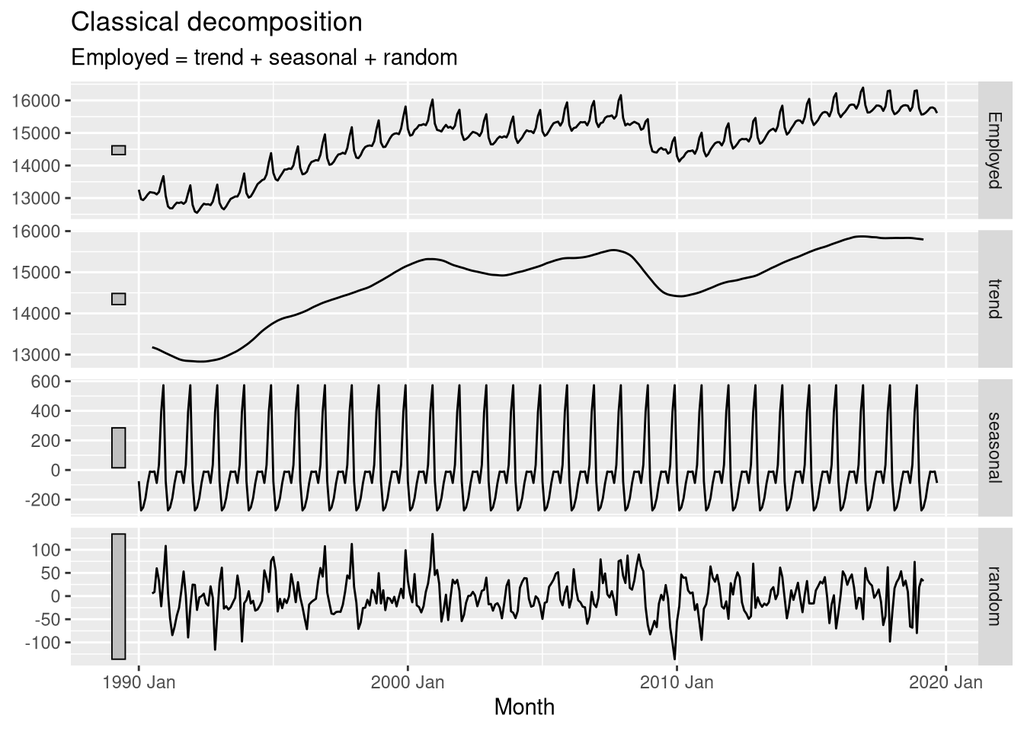

```r
classical_dec |>
  autoplot()
```

# Exercise 1

Consider the last five years of the Gas data from `aus_production`

```r
gas <- tail(aus_production, 5*4) |> select(Gas)
gas
```

```
# A tsibble: 20 x 2 [1Q]
     Gas Quarter
   <dbl>   <qtr>
 1   221 2005 Q3
 2   180 2005 Q4
 3   171 2006 Q1
 4   224 2006 Q2
 5   233 2006 Q3
 6   192 2006 Q4
 7   187 2007 Q1
 8   234 2007 Q2
 9   245 2007 Q3
10   205 2007 Q4
11   194 2008 Q1
12   229 2008 Q2
13   249 2008 Q3
14   203 2008 Q4
15   196 2009 Q1
16   238 2009 Q2
17   252 2009 Q3
18   210 2009 Q4
19   205 2010 Q1
20   236 2010 Q2
```

1. Use `classical_decomposition` with `type=multiplicative` to calculate the trend-cycle and seasonal components
2. Compute and plot the seasonally adjusted data.
3. Change one observations to be an outlier (e.g., add 300 to one observation), and recompute the seasonally adjusted data. What is the effect of the outlier?
4. Does it make any difference if the outlier is near the end rather than in the middle of the series?